# The Country-level Impact of Educational Patterns on the Rate of Entrepreneurship

Sam Dundon and Thierry Racaud

October 24, 2014

*Introduction to Collaborative Social Science Data Analysis*

### Research Interest

The process of allocating public funds for education is an opportunity to make calculated long-term investments in a nation’s populace. The rationale for decisions made during this process, however, is often difficult to understand. For example, while many claims have been made in entrepreneurship literature regarding the importance of cultural and educational factors – not just structural and economic factors – in determining individual and societal tendencies to start a business, these factors are often not included in the decisionmaking process. As a matter of fact, only a few empirical studies have actually been carried out on this topic and most of them focused on which attitudes were favorable to starting a business, while almost none explored how cultural patterns affected these dispositions.

When cultural factors are examined, they are considered as a given feature that can hardly be traced. By having a closer look at education systems, however, we intend to explore the processes through which some of these cultural patterns are enhanced and passed from one generation to the next. Aside from parental education, schools are indeed the very place where children are taught how to fit into society. This research is an attempt to analyze one trait in particular, self-confidence.

### Research Question

Drawing a comparison between France and Britain, to what extent do the behavioral characteristics of the education system - individualistic, group-oriented, and more or less positive reinforcement in teaching - affect the rate of entrepreneurship in each country?

### Literature Review

What determines entrepreneurship at a country-level has been long searched already but although economic, demographic or geographic factors have been looked at extensively, much less has been done regarding cultural or educational factors. However, as Freytag and Thurik stated in 2007, “the relative stability of differences in entrepreneurship across countries suggests that factors other than economic ones are at play” (Andreas and Roy 2007) . Even if “in recent years research has increasingly devoted itself to the subject” (OECD 2009), a lot still needs to be done, as the few studies that explored the relationship between attitudes and foundation activities barely searched what determined these attitudes.

Over a hundred years has passed since Max Weber tried to explain how religious-ethical motivations affect entrepreneurship (Weber et al.), and religion may be less effective in justifying why some are more likely to start businesses than others. Still, that was a founding stone and it is now widely admitted that “cultural features influence attitudes towards start-ups and that these attitudes, in turn, have an impact on start-up activities” (OECD 2009).

Despite various claims of the existence of a cultural effect, few empirical studies have actually been carried out. It took a few decades more before Davidsson, along with Delmar at first (1992), then alone (1995), and then with Wiklund (Davidsson and Wiklund 1997), at his turn, laid a stepping stone by investigating the relationship between structural factors – mainly economic, and cultural factors. As they compared two Swedish regions similar in terms of structure and observed different outcomes, they concluded there may be a small cultural effect in attitudes toward start-up activities.

This thesis is an attempt at finding out whether different patterns in education lead to different outcomes in terms of start-up activities. Indeed, like many in the education literature tend to assert, we believe school personnel have an affect on student self-esteem (Scott et al. 1996). We will further explore how this mechanism works. As for entrepreneurship literature, it generally acknowledges the influence of self-confidence on start-up activities, although “self-confidence in one’s own capabilities to start a business has been found to depend almost exclusively on the individual features of the respective person and his or her integration into social networks” (OECD 2009). We intend to show that these individual characteristics are partly shaped at an institutional and collective level through the education systems and staff attitudes.

Of course, King and Sobel (A. and S. 2008), among others, have already tried to show how school choice can increase the rate of youth entrepreneurship, but their perspective was slightly different. They asserted that a more business-like environment in K-12 education was the key, which was favored by voucher programs. We believe there is a more widely spread systematic effect of cultural and educational patterns. David Watkins (David 2010) cross-cultural perspective on teaching and learning shall be useful in that respect. Kai-Ming Cheng and Kam-Cheung Wong’s study about school effectiveness in East Asia (Cheng and Wong 1996) could also be of help.

Also, as self-confidence is considered to rely partly on one’s integration within social networks (OECD 2009), we will refer to cross-cultural studies such as that of Green, Deschamps and Páez (Green, Deschamps, and Paez 2005) about individualism and collectivism, what Freeman (Freeman 1997) called idiocentrism and allocentrism. Raeff, Greenfield and Quiroz (2000) have also conceptualized interpersonal relationships in both contexts. More school-focused, Yamauchi (Yamauchi 1998) as well as Davies and Aurini (Davies and Aurini 2003) have looked at individualism and collectivism in the classroom and in pedagogy respectively. All these will be important on the way.

Besides direct or indirect school effects, we will necessarily look into entrepreneurship and its determinants at large. Thus we will quote Grilo and Thurik’s research (I. and A.R. 2005) about what determines entrepreneurship engagement levels throughout the European Union, and also Wennekers Sander, Ulhaner Lorraine and Thurik Roy’s explanation of variation across countries (Sander, Lorraine, and Roy 2002). Eventually, with Gartner (B. 1990) we will have a closer look at entrepreneurship’s underlying meanings in research and, along with Acs, Desai and Klapper (J., Sameeksha, and F. 2008), we will ask ourselves what “entrepreneurship” data really shows.

### Analytical Method

#### Hypothesis

Our main hypothesis is that the more self-confident a population is on average, the higher entrepreneurship in that country will be.

#### Causal Chain

Stronger culture of positive reinforcement —> higher degree of individual self-esteem —> higher probability an individual will become an entrepreneur —> higher rate of entrepreneurship at a country-level.

#### Estimation Strategy

The estimation strategy will consist of using cross-sectional data about France and Britain at different points in time regarding the sense of belonging to a group, self-confidence patterns and the entrepreneurship features of each country.

##### Entrepreneurship as a dependent variable

The dependent variable will be the rate of entrepreneurship with its related activities or attitudes as defined by the [Global Entrepreneurship Monitor (GEM)](http://www.gemconsortium.org):

- Established Business Ownership Rate;
- Entrepreneurial intention; and
- Entrepreneurship as desirable career choice.

Note: The GEM measure of entrepreneurship is often used or referred to in OECD studies.

##### Self-confidence as the key explanatory variable

The key explanatory variable will be the degree of self confidence. As we did not find so far any satisfactory proxy for self-confidence in the way we intend to define it, we will need to compute an index. In order to do so, we will rely on both [OECD PISA 2012](http://www.oecd.org/pisa/keyfindings/pisa-2012-results.htm), [World Value Survey 2005-2009](http://www.worldvaluessurvey.org/WVSOnline.jsp) and [GEM](http://www.gemconsortium.org)

From PISA 2012, we will use the items regarding engagement, drive and self-beliefs (Table III.2.3.a). This data is available in Excel format from the OECD. More specifically, we will compute data regarding the sense of belonging to measure the strength of inclusion in social networks. We will also process measures of self-perception. They all come as a percentage of the country-representative student population.

From World Value Survey, we will use the latest data available, that of the fifth wave (2005-2009). Our main issue is that data was collected at different points in time in Britain (2005) and in France (2006), but in both cases before the economic crisis, which might have affected people’s prospects and values differently. We will specifically look at the following items:

V86 How important are adventure and taking risks to the person surveyed?  
V119 How good is competition?

From GEM, we will use the most recent data available regarding the fear of failure rate and perceived capabilities.

To compute these data together is quite a challenge and we are not yet fully sure on how to proceed. But at least, these multiple reliable measures from well-recognized sources should give us a composite but also comprehensive indicator about the average degree of self-confidence of individuals in each country.

##### Social inclusion as a complementary explanatory variable

As we mentioned that self-confidence also depends on the integration in social networks, we will partly rely on the sense of belonging as defined by OECD PISA study, but again we will need to compute an index. In order to do so, we will also rely on the following items from the World Value Survey 2005-2009 wave about “sense of belonging to a group“ and “sense of individuality”.

V65 I seek to be myself rather than to follow others  
V66 I live up to what my friends expect  
V67 I decide my goals in life by myself  
V78 How good / bad is greater respect for authority to the person surveyed?  
V186 How often do you attend religious services?  
V198 How justifiable can claiming government benefits be?  
V199 How justifiable can avoiding a fare on public transport be?  
V200 How justifiable can cheating on taxes be?

##### Other classic determinants of entrepreneurship as control variables

We will obviously need to control for the economic outlook at the time of data collection about entrepreneurship characteristics. We will also need to control for nine key entrepreneurship conditions as defined in the [National Experts Survey (NES)](http://www.gemiran.ir/sec/gem/?@=28) that may affect the rate of entrepreneurship. These nine conditions are the following:

1. Finance
2. Government policies
3. Government programs
4. Entrepreneurial Education and Training
5. Research and Development Transfer (R & D)
6. Commercial and professional infrastructure
7. Internal Market openness
8. Physical infrastructure and services
9. Cultural and social norms

We are not yet fully sure on how to best control for all these variables though and will work on this in the coming weeks.

##### Process

The first step will be to see if, regarding self-confidence, different patterns can be observed in each country. In which case, we may need to call on cultural explanations.

Then, should indeed different patterns be observed, we will proceed to an Ordinary Least Square (OLS) Regression to determine the extent of the affect of these characteristics on the rate of entrepreneurship in each country.

### Necessary Concepts

1. Self-confidence: It is difficult to obtain a credible measurement of self confidence, but we will compute an index to include a quantitative approach in measuring this factor.
2. Positive reinforcement: Again, even if this is not easy to characterize quantitatively, we will attempt to compute an index and characterize it on a scale. Should we eventually consider there is considerable positive reinforcement in one country and very little in another, perhaps we could go as far as using a dummy variable.
3. Culture: Key concept broadly understood here as the set of beliefs, values, norms and practices of a given society.
4. Education: Here education is understood as the process of apprenticeship that takes place in school throughout compulsory years (from the age of 6 to 16). Thus we examine the average potential effect of these years of “shaping” on individuals for the entire population of a country.
5. Return on Investment: Future benefits of a euro spent at present. Here, return on investment would only start to be visible after some time, once most of a generation has got into active life which may take up to five to ten years. But even then, not all the expected propensity to start a business will be palpable. When you add it to the mechanism of the social discount rate, that huge distance in time as of now seem to prevent any calculations of return on investment when it comes to public budgeting for education policies.
6. Individual vs. societal factors: The below chart identifies several of the individual and societal factors impacting the decision to become an entrepreneur.

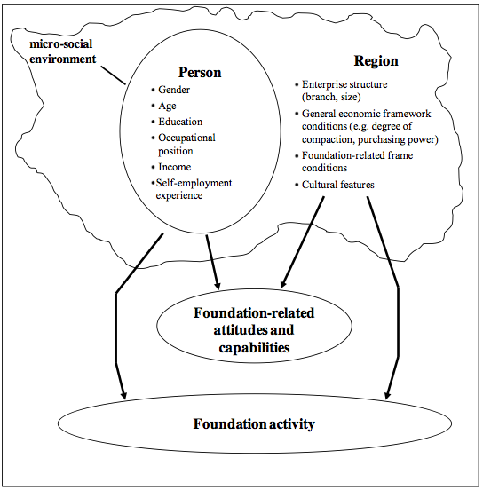

Source: OECD Local Entrepreneurship Reviews (OECD 2009)

### Conclusion

The impact of cultural factors in education on the rate of entrepreneurship in a given country is an important and under-researched topic that should be considered by policymakers constructing public education budgets. Through this project, we hope to encourage the consideration of these cultural factors by providing a qualitative and quantitative method for understanding the impact of these factors. Although several challenges remain to compiling the indexes discussed in this report, we are confident we can produce a helpful framework for examining and understanding these factors.

References

A., King Kerry, and Sobel Russel S. 2008. “Does School Choice Increase the Rate of Youth Entrepreneurship?” *Economics of Education Review* 27 (4): 429–38.

Andreas, Freytag, and Thurik Roy. 2007. “Entrepreneurship and Its Determinants in a Cross-Country Setting.” *Journal of Evolutionary Economics* 17 (2): 117–31.

B., Gartner William. 1990. “What Are We Talking About When We Talk About Entrepreneurship.” *Journal of Business Venturing* 5 (1): 15–28.

Cheng, Kai-Ming, and Kam-Cheung Wong. 1996. “School Effectiveness in East-Asia: Concepts, Origins and Implications.” *Journal of Educational Administration* 34 (5): 32–49.

David, Watkins. 2010. “Learning and Teaching: A Cross-Cultural Perspective.” *School Leadership and Management, Formerly School Organisation* 20 (2): 161–73.

Davidsson, Per, and Johan Wiklund. 1997. “Values, Beliefs and Regional Variations in New Firm Formation Rates.” *Journal of Economic Psychology* 18 (2). Elsevier: 179–99.

Davies, Scott, and Janice Aurini. 2003. “Homeschooling and Canadian Educational Politics: Rights, Pluralism and Pedagogical Individualism.” *Evaluation & Research in Education* 17 (2-3). Taylor & Francis: 63–73.

Freeman, Mark A. 1997. “Demographic Correlates of Individualism and Collectivism a Study of Social Values in Sri Lanka.” *Journal of Cross-Cultural Psychology* 28 (3). Sage Publications: 321–41.

Green, Eva GT, Jean-Claude Deschamps, and Dario Paez. 2005. “Variation of Individualism and Collectivism Within and Between 20 Countries a Typological Analysis.” *Journal of Cross-Cultural Psychology* 36 (3). Sage Publications: 321–39.

I., Grilo, and Thurik A.R. 2005. “Determinants of Entrepreneurial Engagement Levels in Europe and the US.” *Max Plack Institute of Economics, Papers on Entrepreneurship, Growth and Public Policy* 25.

J., Acs Zoltan, Desai Sameeksha, and Klapper Leora F. 2008. “What Does ‘Entrepreneurship’ Data Really Show?” *Small Business Economics* 31: 265–81.

OECD. 2009. “Strengthening Entrepreneurship and Economic Development in East-Germany - Lessons of Local Approaches.” *Journal of Evolutionary Economics* 2 (1): 59–72.

Raeff, Catherine, Patricia Marks Greenfield, and Blanca Quiroz. 2000. “Conceptualizing Interpersonal Relationships in the Cultural Contexts of Individualism and Collectivism.” *New Directions for Child and Adolescent Development* 2000 (87). Wiley Online Library: 59–74.

Sander, A.R.M. Wennekers, L.M. Ulhaner Lorraine, and A.R. Thurik Roy. 2002. “Entrepreneurship and Its Conditions: A Macro Perspective.” *International Journal of Entrepreneurship Education (IJEE)* 1 (1): 25–64.

Scott, Cynthia G., Dustin E. Richard, Mertens Carol, and Murray Gerald C. 1996. “Student Self-Esteem and the School System: Perceptions and Implications.” *Journal of Educational Research* 89 (5): 286–93.

Weber, Max, Michael D Coe, Talcott Parsons, and RH Tawney. “The Protestant Ethic and the Spirit of Capitalism.”

Yamauchi, Lois A. 1998. “Individualism, Collectivism, and Cultural Compatibility: Implications for Counselors and Teachers.” *The Journal of Humanistic Education and Development* 36 (4). Wiley Online Library: 189–98.